# Figure 4

Jaime So

8/30/2021

# Figure 4: VSG expression reflects the genomic VSG repertoire of the infecting parasites

Tb427 and Tbg972:

- Sequences acquired from TriTrypDB
- Tb427 has recently been re-characterized so we used most up-to-date assembly and identified VSG sequences from the genome sequence using HMMscan
- VSG identified by match to one or more VSG HMM at e-val <= 1e-5
- annotation information is included in the fasta ID, or in separate file in the case of Tb427
- run the find_VSG_nterm.py pipeline on reference VSGenomes

# Fig. 4A

Compare highly expressed mouse VSG over all time points to the genomic repertoire of infecting strain EATRO1125

- EATRO VSG sequences obtained from George Cross’s website: https://tryps.rockefeller.edu/Sequences.html
- EATRO VSGs typed using HMM pipeline find_VSG_nterm.py

Columns show the proportion of VSG types identified in each mouse infection over all time points and the proportion of VSG types in the infecting T. b. brucei strain, EATRO 1125. The total number of unique VSG sequences is displayed above each column.

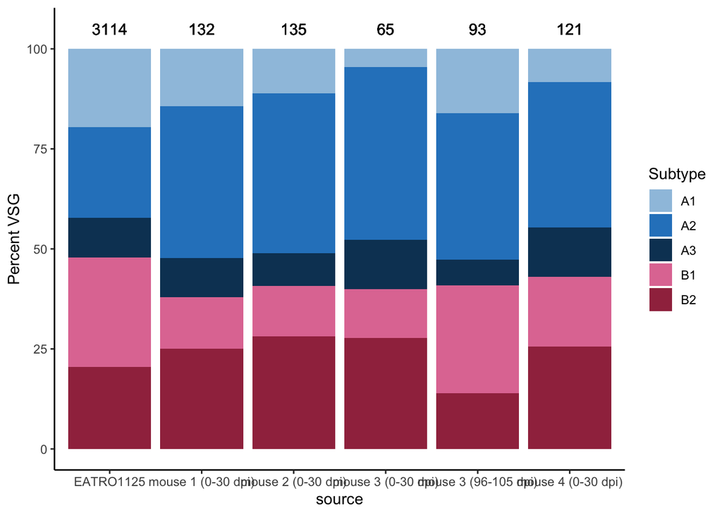

```r
# compare mouse to EATRO1125 reference strain genomic VSG repertoire
# this is the parasite strain the mice were infected with
mouse <- read_csv("FigureData/Mugnier2015_allMiceTyped.csv")
# I will exclude untyped VSG
# extract all unique VSG sequence IDs and their types, drop rows with dulicated data
# make sure the VSG that are shared between mice are still represented in all mice
mouse <- mouse[complete.cases(mouse), ] %>% select(VSG, mouse, time, nterm_typesubtype) %>% .[!duplicated(.), ]

# compare individual mice, for mouse three split early (0-30 dpi) and late (96-105 dpi)
mouse <- mouse %>% group_by(mouse, time, nterm_typesubtype) %>% summarise(n = n())
# summarize further, find percent by type, rename source for plotting
# organize the plot so I can bind to a summary of the refernce Tb1125 repertoire
mouse <- mouse %>% mutate(source = ifelse(time == "early", " (0-30 dpi)", " (96-105 dpi)")) %>% group_by(mouse, time) %>% mutate(total = sum(n)) %>% ungroup() %>% mutate(percent = (n / total)*100) %>% select(mouse, source, nterm_typesubtype, n, total, percent)

mouse <- mouse %>% mutate(source = paste0(sub("m", "mouse ", mouse), source)) %>% select(source, nterm_typesubtype, n, total, percent)

EATRO1125types <- read_csv("FigureData/vsgs_tb1125_nodups_atleast250aas_pro_NtermSummary.csv")
# make subtypes that are "NA" "unknown" instead to make plotting easier
EATRO1125types <- EATRO1125types %>% mutate(nterm_typesubtype = replace_na(nterm_typesubtype, "unknown"))

# exclude untyped VSG
plotEATRO <- EATRO1125types[!EATRO1125types$nterm_typesubtype == "unknown", ] %>% mutate(source = "EATRO1125") %>%  group_by(source, nterm_typesubtype) %>% summarise(n = n()) %>% mutate(total = sum(n)) %>% mutate(percent = (n / total)*100)  %>% ungroup()
plotEATRO <- bind_rows(plotEATRO, mouse)


Fig4A <- plotEATRO %>% ggplot(aes(x = source, y = percent, fill = nterm_typesubtype)) +
  geom_bar(stat = "identity") +
  scale_fill_manual(values = c("#9EC3E0", "#2A84C6", "#0B4063", "#E17AA2", "#A1324D")) +
  scale_y_continuous(limits = c(0, 105)) +
  theme_classic() +
  ylab("Percent VSG") +
  labs(fill = "Subtype") +
  geom_text(data = plotEATRO, aes(x = source, y = 105, label = total, fill = NULL))
Fig4A
```

## construct contingency tables to calculate chi-square statistic

is the observed type expression dependent on the composition of the repertoire?

**Calculate expected frequencies**

- Does the observed count for each set of VSG differ from the expected frequency (i.e. the proportion of types in the genomic repertoire of EATRO 1125)?

```r
# the proportion of each type
plotEATRO %>% mutate(nterm_type = sub("[[:digit:]]", "", .$nterm_typesubtype)) %>% group_by(source, nterm_type) %>% summarise(comp = sum(percent)/100)
```

```
## # A tibble: 12 × 3
## # Groups:   source [6]
##    source               nterm_type  comp
##    <chr>                <chr>      <dbl>
##  1 EATRO1125            A          0.521
##  2 EATRO1125            B          0.479
##  3 mouse 1 (0-30 dpi)   A          0.621
##  4 mouse 1 (0-30 dpi)   B          0.379
##  5 mouse 2 (0-30 dpi)   A          0.593
##  6 mouse 2 (0-30 dpi)   B          0.407
##  7 mouse 3 (0-30 dpi)   A          0.6
##  8 mouse 3 (0-30 dpi)   B          0.4
##  9 mouse 3 (96-105 dpi) A          0.591
## 10 mouse 3 (96-105 dpi) B          0.409
## 11 mouse 4 (0-30 dpi)   A          0.570
## 12 mouse 4 (0-30 dpi)   B          0.430
```

```r
# do the observed frequencies differ significantly from the expected?

EATROproportions <- plotEATRO %>% mutate(nterm_type = sub("[[:digit:]]", "", .$nterm_typesubtype)) %>% group_by(source, nterm_type) %>% summarise(comp = sum(percent)/100)
# the proportions of A and B types of EATRO 1125 represent our expected frequencies
expected <- EATROproportions[EATROproportions$source == "EATRO1125", ] %>% .$comp
expected
```

```
## [1] 0.5208735 0.4791265
```

**Make contingency table and calculate chi-square using counts of A-types and B-types by source**

```r
plotEATRO %>% mutate(nterm_type = sub("[[:digit:]]", "", .$nterm_typesubtype)) %>% group_by(source, nterm_type) %>% summarise(comp = sum(n))
```

```
## # A tibble: 12 × 3
## # Groups:   source [6]
##    source               nterm_type  comp
##    <chr>                <chr>      <int>
##  1 EATRO1125            A           1622
##  2 EATRO1125            B           1492
##  3 mouse 1 (0-30 dpi)   A             82
##  4 mouse 1 (0-30 dpi)   B             50
##  5 mouse 2 (0-30 dpi)   A             80
##  6 mouse 2 (0-30 dpi)   B             55
##  7 mouse 3 (0-30 dpi)   A             39
##  8 mouse 3 (0-30 dpi)   B             26
##  9 mouse 3 (96-105 dpi) A             55
## 10 mouse 3 (96-105 dpi) B             38
## 11 mouse 4 (0-30 dpi)   A             69
## 12 mouse 4 (0-30 dpi)   B             52
```

```r
comp1125 <- plotEATRO %>% mutate(nterm_type = sub("[[:digit:]]", "", .$nterm_typesubtype)) %>% group_by(source, nterm_type) %>% summarise(comp = sum(n)) %>% .$comp
contingency1125 <- matrix(comp1125, nrow = 2, ncol = 6, byrow = F, dimnames = list(c("A", "B"), c(unique(EATROproportions$source))))

# chi-squared test of independence on the whole table
# this tests whether there is a relationship between source and type (A or B)
contingency1125
```

```
##   EATRO1125 mouse 1 (0-30 dpi) mouse 2 (0-30 dpi) mouse 3 (0-30 dpi)
## A      1622                 82                 80                 39
## B      1492                 50                 55                 26
##   mouse 3 (96-105 dpi) mouse 4 (0-30 dpi)
## A                   55                 69
## B                   38                 52
```

```r
chisq.test(contingency1125, correct = F)
```

```
##
##  Pearson's Chi-squared test
##
## data:  contingency1125
## X-squared = 10.995, df = 5, p-value = 0.05149
```

Table of expected frequencies

```r
chisq.test(contingency1125) %>% .$expected
```

```
##   EATRO1125 mouse 1 (0-30 dpi) mouse 2 (0-30 dpi) mouse 3 (0-30 dpi)
## A  1656.546           70.21967           71.81557           34.57787
## B  1457.454           61.78033           63.18443           30.42213
##   mouse 3 (96-105 dpi) mouse 4 (0-30 dpi)
## A             49.47295           64.36803
## B             43.52705           56.63197
```

The table of observed counts

```r
chisq.test(contingency1125) %>% .$observed
```

```
##   EATRO1125 mouse 1 (0-30 dpi) mouse 2 (0-30 dpi) mouse 3 (0-30 dpi)
## A      1622                 82                 80                 39
## B      1492                 50                 55                 26
##   mouse 3 (96-105 dpi) mouse 4 (0-30 dpi)
## A                   55                 69
## B                   38                 52
```

Residuals show positive and negative associations

```r
chisq.test(contingency1125) %>% .$residuals
```

```
##    EATRO1125 mouse 1 (0-30 dpi) mouse 2 (0-30 dpi) mouse 3 (0-30 dpi)
## A -0.8487793           1.405814          0.9657816          0.7520254
## B  0.9048969          -1.498761         -1.0296348         -0.8017460
##   mouse 3 (96-105 dpi) mouse 4 (0-30 dpi)
## A            0.7857953          0.5773383
## B           -0.8377486         -0.6155093
```

- If the p-vlaue not significant, then the relative frequencies of A and B are identical over all sources

**Pairwise comparisons:**

- Do the observed type frequencies in mice differ significantly from the expected proportions in EATRO1125 genomic repertoire

mouse 1

```r
chisq.test(contingency1125[,2], p = expected)
```

```
##
##  Chi-squared test for given probabilities
##
## data:  contingency1125[, 2]
## X-squared = 5.3251, df = 1, p-value = 0.02102
```

mouse 2

```r
chisq.test(contingency1125[,3], p = expected)
```

```
##
##  Chi-squared test for given probabilities
##
## data:  contingency1125[, 3]
## X-squared = 2.7824, df = 1, p-value = 0.0953
```

mouse 3 0-30 dpi

```r
chisq.test(contingency1125[,4], p = expected)
```

```
##
##  Chi-squared test for given probabilities
##
## data:  contingency1125[, 4]
## X-squared = 1.6307, df = 1, p-value = 0.2016
```

mouse 3 96-105 dpi

```r
chisq.test(contingency1125[,5], p = expected)
```

```
##
##  Chi-squared test for given probabilities
##
## data:  contingency1125[, 5]
## X-squared = 1.8534, df = 1, p-value = 0.1734
```

mouse 4

```r
chisq.test(contingency1125[,6], p = expected)
```

```
##
##  Chi-squared test for given probabilities
##
## data:  contingency1125[, 6]
## X-squared = 1.182, df = 1, p-value = 0.277
```

observed type frequencies in mouse infections do not consistently significantly differ from the expected proportions

- only mouse 1 had p-value < 0.05
- chi-square on whole table had p-value > 0.05, suggesting relative independence of variables.

In other words, no difference in A/B frequency between repertoire and expressed VSG types

# Fig. 4B

```r
# import all typed Lister 427 VSGs
Tb427types <- read_csv("FigureData/VSG.TbruceiLister427_2018_NtermSummary.csv")
# import typed TbgDAL972
DAL972types <- read_csv("FigureData/VSG.TbruceigambienseDAL972_NtermSummary.csv")
# import rhodesiense patient data
rhodesiense <- read_csv("Supptable5_tbrVSGexpression.csv")
#drop patient 74 since it was sequenced differently than all the others
rhodesiense <- rhodesiense[!rhodesiense$patient_number == "74", ]

# drop duplicates, pick out the types of each unique cluster
rhodesiense <- rhodesiense %>% select(cdHit_ID, nterm_typesubtype) %>% .[!duplicated(.$cdHit_ID), ]

rhodesiense <- rhodesiense %>% mutate(source = "T.b. rhodesiense Patient") %>%  group_by(source, nterm_typesubtype) %>% summarise(n = n()) %>% mutate(total = sum(n)) %>% mutate(percent = (n / total)*100)  %>% ungroup()
rhodesiense
```

```
## # A tibble: 6 × 5
##   source                   nterm_typesubtype     n total percent
##   <chr>                    <chr>             <int> <int>   <dbl>
## 1 T.b. rhodesiense Patient A1                    3    77    3.90
## 2 T.b. rhodesiense Patient A2                   22    77   28.6
## 3 T.b. rhodesiense Patient A3                    3    77    3.90
## 4 T.b. rhodesiense Patient B1                   15    77   19.5
## 5 T.b. rhodesiense Patient B2                   29    77   37.7
## 6 T.b. rhodesiense Patient unknown               5    77    6.49
```

```r
# the unknown VSG in rhodesiense set did not have detectable N-terminal domains by our hmmscan analysis, which required a 1e-5 e-value match to the hmm profile
# our ncbi blast of all assembled sequence clusters suggested that these sequences were VSG, they are likely to be incompletely assembled.
# this makes sense considering the low calculated expression level of these unknowns, they may have been rare variants and the un-enriched RNA-seq did not provide the depth for them to assemble completely

# import gambiense patient data
gambiense <- read_csv("Supptable3_tbgVSGexpression.csv")
# drop duplicates, pick out the types of each unique cluster
gambiense <- gambiense %>% select(cdHit_ID, nterm_typesubtype) %>% .[!duplicated(.$cdHit_ID), ]

gambiense <- gambiense %>% mutate(source = "T.b. gambiense Patient") %>%  group_by(source, nterm_typesubtype) %>% summarise(n = n()) %>% mutate(total = sum(n)) %>% mutate(percent = (n / total)*100)  %>% ungroup()
gambiense
```

```
## # A tibble: 5 × 5
##   source                 nterm_typesubtype     n total percent
##   <chr>                  <chr>             <int> <int>   <dbl>
## 1 T.b. gambiense Patient A1                    1    44    2.27
## 2 T.b. gambiense Patient A2                    3    44    6.82
## 3 T.b. gambiense Patient A3                    4    44    9.09
## 4 T.b. gambiense Patient B1                   15    44   34.1
## 5 T.b. gambiense Patient B2                   21    44   47.7
```

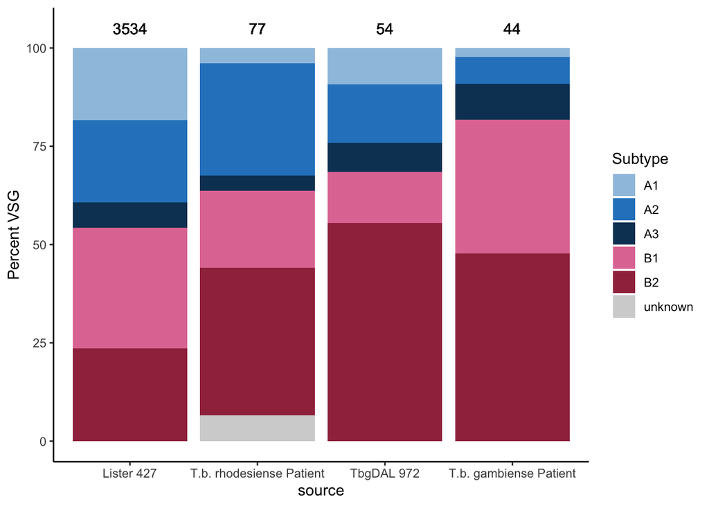

```r
plot427 <- Tb427types %>% mutate(source = "Lister 427") %>%  group_by(source, nterm_typesubtype) %>% summarise(n = n()) %>% mutate(total = sum(n)) %>% mutate(percent = (n / total)*100)  %>% ungroup()
plotDAL972 <- DAL972types %>% mutate(source = "TbgDAL 972") %>%  group_by(source, nterm_typesubtype) %>% summarise(n = n()) %>% mutate(total = sum(n)) %>% mutate(percent = (n / total)*100)  %>% ungroup()
comparePatient <- bind_rows(rhodesiense, gambiense, plot427, plotDAL972)

Fig4B <- comparePatient %>%
  mutate(source = factor(source, levels = c("Lister 427", "T.b. rhodesiense Patient", "TbgDAL 972", "T.b. gambiense Patient"))) %>%
  ggplot(aes(x = source, y = percent, fill = nterm_typesubtype)) +
  geom_bar(stat = "identity") +
  scale_fill_manual(values = c("#9EC3E0", "#2A84C6", "#0B4063", "#E17AA2", "#A1324D", "lightgrey")) +
  scale_y_continuous(limits = c(0, 105)) +
  theme_classic() +
  ylab("Percent VSG") +
  labs(fill = "Subtype") +
  geom_text(data = comparePatient, aes(x = source, y = 105, label = total, fill = NULL))
Fig4B
```

## Construct contingency tables to calculate chi-square statistic

- find the proportion of each VSG type within genome
- Lister 427 has the most complete VSGenome with 3534 annotated and previously-typed sequences
- we will use Lister 427 as the basis of comparison, it represents the underlying genomic repertoire and thus the expected proportions of A and B types

```r
comparePatient[!comparePatient$nterm_typesubtype == "unknown", ] %>% mutate(nterm_type = sub("[[:digit:]]", "", .$nterm_typesubtype)) %>% group_by(source, nterm_type) %>% summarise(comp = sum(percent)/100)
```

```
## # A tibble: 8 × 3
## # Groups:   source [4]
##   source                   nterm_type  comp
##   <chr>                    <chr>      <dbl>
## 1 Lister 427               A          0.458
## 2 Lister 427               B          0.542
## 3 T.b. gambiense Patient   A          0.182
## 4 T.b. gambiense Patient   B          0.818
## 5 T.b. rhodesiense Patient A          0.364
## 6 T.b. rhodesiense Patient B          0.571
## 7 TbgDAL 972               A          0.315
## 8 TbgDAL 972               B          0.685
```

```r
comparePatient
```

```
## # A tibble: 21 × 5
##    source                   nterm_typesubtype     n total percent
##    <chr>                    <chr>             <int> <int>   <dbl>
##  1 T.b. rhodesiense Patient A1                    3    77    3.90
##  2 T.b. rhodesiense Patient A2                   22    77   28.6
##  3 T.b. rhodesiense Patient A3                    3    77    3.90
##  4 T.b. rhodesiense Patient B1                   15    77   19.5
##  5 T.b. rhodesiense Patient B2                   29    77   37.7
##  6 T.b. rhodesiense Patient unknown               5    77    6.49
##  7 T.b. gambiense Patient   A1                    1    44    2.27
##  8 T.b. gambiense Patient   A2                    3    44    6.82
##  9 T.b. gambiense Patient   A3                    4    44    9.09
## 10 T.b. gambiense Patient   B1                   15    44   34.1
## # … with 11 more rows
```

```r
proportions427 <- comparePatient %>% mutate(nterm_type = sub("[[:digit:]]", "", .$nterm_typesubtype)) %>% group_by(source, nterm_type) %>% summarise(comp = sum(percent)/100)
```

- the proportions of A and B types represent our expected frequencies

expected values based on Lister427 genomic VSG

```r
expected427 <- proportions427[proportions427$source == "Lister 427", ] %>% .$comp
expected427
```

```
## [1] 0.4575552 0.5424448
```

expected values based on TbgDAL972 genomic VSG

```r
expectedDAL <- proportions427[proportions427$source == "TbgDAL 972", ] %>% .$comp
expectedDAL
```

```
## [1] 0.3148148 0.6851852
```

**Contingency table:**

- calculate chi square using counts of A types and B types by source

```r
compPatient <- comparePatient %>% mutate(nterm_type = sub("[[:digit:]]", "", .$nterm_typesubtype)) %>% group_by(source, nterm_type) %>% summarise(comp = sum(n)) %>% .$comp
contingencyPatient <- matrix(compPatient, nrow = 2, ncol = 4, byrow = F, dimnames = list(c("A", "B"), c("Lister 427", "gambiense", "rhodesiense", "TbgDAL 972")))
contingencyPatient
```

```
##   Lister 427 gambiense rhodesiense TbgDAL 972
## A       1617         8          28          5
## B       1917        36          44         17
```

**chi-squared test of independence on the whole table**

- this tests whether there is a relationship between source and type (A or B)

```r
chisq.test(contingencyPatient)
```

```
##
##  Pearson's Chi-squared test
##
## data:  contingencyPatient
## X-squared = 19.051, df = 3, p-value = 0.0002668
```

Table of expected frequencies

```r
chisq.test(contingencyPatient) %>% .$expected
```

```
##   Lister 427 gambiense rhodesiense TbgDAL 972
## A    1595.69   19.8671     32.5098   9.933551
## B    1938.31   24.1329     39.4902  12.066449
```

The table of observed counts

```r
chisq.test(contingencyPatient) %>% .$observed
```

```
##   Lister 427 gambiense rhodesiense TbgDAL 972
## A       1617         8          28          5
## B       1917        36          44         17
```

Residuals show positive and negative associations

```r
chisq.test(contingencyPatient) %>% .$residuals
```

```
##   Lister 427 gambiense rhodesiense TbgDAL 972
## A  0.5334805 -2.662425  -0.7909526  -1.565335
## B -0.4840398  2.415683   0.7176505   1.420267
```

**Take a closer look at individual associations**

counts of expressed T.b. gambiense N-domain types

```r
contingencyPatient[,2]
```

```
##  A  B
##  8 36
```

```r
chisq.test(contingencyPatient[,2], p = expected427)
```

```
##
##  Chi-squared test for given probabilities
##
## data:  contingencyPatient[, 2]
## X-squared = 13.479, df = 1, p-value = 0.0002413
```

- significant, reject null. observed A and B type frequency differs from expected

compare to the proportions present in annotated TbgDAL 972 genome

```r
chisq.test(contingencyPatient[,2], p = expectedDAL)
```

```
##
##  Chi-squared test for given probabilities
##
## data:  contingencyPatient[, 2]
## X-squared = 3.608, df = 1, p-value = 0.0575
```

compare Tbg DAL972 frequency to lister 427

```r
chisq.test(contingencyPatient[,4], p = expected427)
```

```
##
##  Chi-squared test for given probabilities
##
## data:  contingencyPatient[, 4]
## X-squared = 4.7005, df = 1, p-value = 0.03015
```

counts of expressed T.b. rhodesiense N-domain types

```r
contingencyPatient[,3]
```

```
##  A  B
## 28 44
```

```r
chisq.test(contingencyPatient[,3], p = expected427)
```

```
##
##  Chi-squared test for given probabilities
##
## data:  contingencyPatient[, 3]
## X-squared = 1.3678, df = 1, p-value = 0.2422
```

- do not reject null, not a significant difference

Tbr paitent compared to DAL972

```r
chisq.test(contingencyPatient[,3], p = expectedDAL)
```

```
##
##  Chi-squared test for given probabilities
##
## data:  contingencyPatient[, 3]
## X-squared = 1.8315, df = 1, p-value = 0.176
```

Tbr patient compared to Tbg patient frequencies

```r
chisq.test(contingencyPatient[,c(2,3)])
```

```
##
##  Pearson's Chi-squared test with Yates' continuity correction
##
## data:  contingencyPatient[, c(2, 3)]
## X-squared = 4.5466, df = 1, p-value = 0.03298
```

By [Jaime So](https://github.com/JSoSci/) for the [Mugnier Lab](https://www.mugnierlab.org/)

*jso4@jhmi.edu*